# Stochastic Volatility Model

> Reference: Python for Finance by Yves Hilpisch, O'Reilly Media, Chapter 10, Stochastics

### Multidimensional Stochastic Processes

```python
import numpy as np
import numpy.random as npr
import matplotlib.pyplot as plt
import pandas as pd
import scipy as sp
import scipy.linalg
import scipy.stats
```

Features of the implied volatility surface such as volatility smile and skew indicate that implied volatility varies with respect to strike price and expiry. Is it also a function of the underlying price?

The Heston SV model assumes that the variance is a random process that exhibits:

Geometric Brownian motion SDE:

$dS_t = rS_tdt + \sqrt{v_t} S_t dZ_t^1$, where $v_t = \sigma_t^2 $

$ S_t = S_{t-dt} exp [ (r- v_t/2)dt + \sqrt{v_t} \sqrt{dt} z_t^1 ] $

AR1 process for the variance of the process:

$dv_t = k_v(\theta_v-v_t)dt + \sigma_v \sqrt{v_t} dZ_t^2$, where $\theta$ is the long-term mean of the variance process.

$dZ_t^1dZ_t^2 = \rho dt$

I have read but not verified that the condition $ k_v \theta_v > \sigma^2_v/2 $ ensures positivity of the variance process.

```python
#Simulate N process paths with arbitrary parameters:
I=100
v0=0.1
sigmav = 0.1 # std deviation factor of the variance process
k = 3.0
th = 0.25 #theta
r = 0.05
T = 1
M=50
dt = T/M
S0=100.
rho = -0.6
```

To account for the correlation between two stochastic processes, we need to perform the Choleski decomposition of the correlation matrix. A hermitic(...) positive-definite matrix $A = LL^*$, the product of two triangular matrices. If $A$ is symmetric (which is true iff $A$ is real), the factorization may be written $A = LL^T$.

```python
corr_mat = np.zeros((2,2))
corr_mat[0,:] = [1.0, rho]
corr_mat[1,:] = [rho, 1.0]
#L = scipy.linalg.cholesky(corr_mat, lower=True)
#U = scipy.linalg.cholesky(corr_mat, lower=False)
chol_mat = np.linalg.cholesky(corr_mat); chol_mat
```

```
array([[ 1. ,  0. ],
       [-0.6,  0.8]])
```

We generate two sets of correlated random numbers, then we use the Euler scheme to take into account the correlation.

```python
rand = npr.standard_normal((2,M+1, I))
v = np.zeros_like(rand[0]) # We need to impose v positive, so we use an auxiliary vh.
vh = np.zeros_like(v)
v[0] = v0
vh[0] = v0

for t in range(1, M+1):
    z = np.dot(chol_mat, rand[:,t,:]) #2-dim process
    clamped = np.maximum(vh[t-1],0)
    vh[t] = vh[t-1] + k*(th-clamped)*dt + sigmav*np.sqrt(clamped)*np.sqrt(dt)*z[1]
    v = np.maximum(vh,0)
```

```python
S = np.zeros_like(rand[0])
S[0] = S0
for t in range(1, M+1):
    z = np.dot(chol_mat, rand[:,t,:])
    S[t] = S[t-1]*np.exp((r-0.5*v[t])*dt + np.sqrt(v[t])*np.sqrt(dt)*z[0])
```

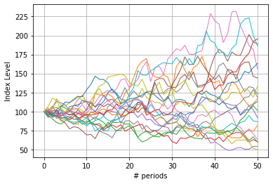

```python
plt.plot(S[:,:20], lw = 1)
plt.xlabel('# periods'); plt.ylabel('Index Level')
plt.grid(True)
#To do: plot on log scale
```

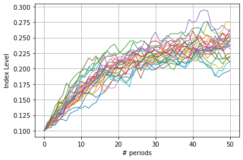

```python
plt.plot(v[:,:25], lw = 1)
plt.xlabel('# periods'); plt.ylabel('Index Level')
plt.grid(True)
```

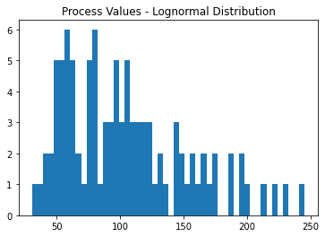

```python
#State variable
# Terminal Value:
ST = S[-1]
#The state variable follows a Lognormal distribution.
fig, ax1 = plt.subplots()#
ax1.hist(ST, bins=50); ax1.set_title('Process Values - Lognormal Distribution')
```

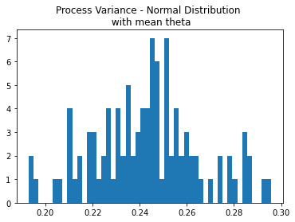

```python
#Variance of the process:
# Terminal Value:
vT = v[-1]
#The state variable follows a Lognormal distribution.
fig, ax1 = plt.subplots()#
ax1.hist(vT, bins=50); ax1.set_title('Process Variance - Normal Distribution \n with mean theta')
```

```python
scipy.stats.describe((S[-1]))
```

```
DescribeResult(nobs=100, minmax=(30.529011677930516, 245.42697805069005), mean=104.35388861375988, variance=2375.9483710690743, skewness=0.8361075659188333, kurtosis=0.07602336542600119)
```

```python
scipy.stats.describe((v[-1]))
```

```
DescribeResult(nobs=100, minmax=(0.19283207326610985, 0.2958076774498704), mean=0.24321525147797518, variance=0.0004992162361855502, skewness=0.11176406215837527, kurtosis=-0.19539346470800556)
```